# Bus delay, today? No way…

Examining how long my flatmates, family and I wait for buses

For the past week, I’ve been asking my siblings and flatmates to track some basic data on their bus trips. Below is what I found when I analysed it.

## When did we catch our buses?

The data for this graph is split into whether we had somewhere to be or not - a “yes” would’ve meant that the person had to be at a class, at work, etc. A “no” meant they didn’t *need* to be where they were going as soon as possible (so perhaps going shopping, returning from work, etc).

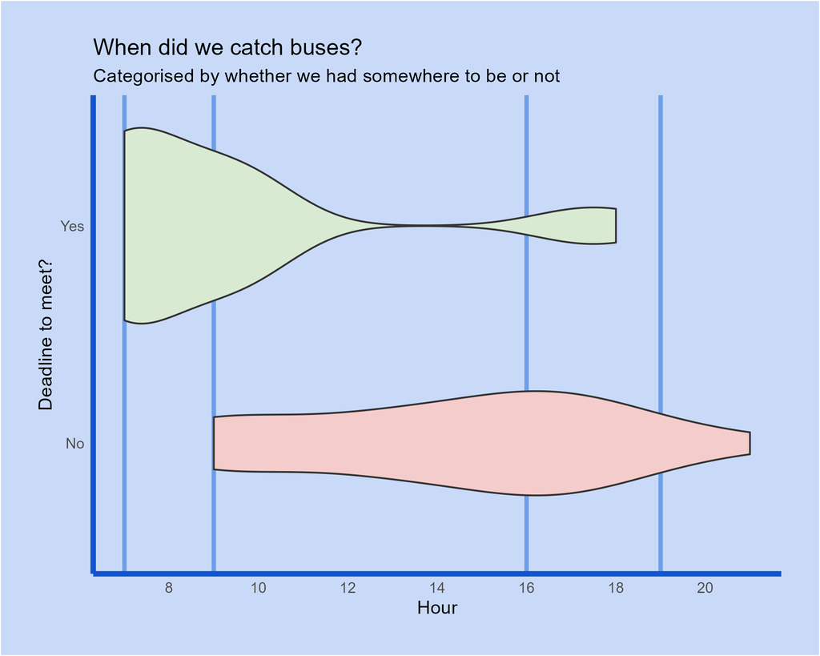

Violin chart showing what hours journeys started at

The two blue columns indicate the morning and evening peak hours. Somewhat unsurprisingly, the biggest peak is the morning for the “yesses”, presumably as people make their way to uni and work. The “nos” are a lot more spread out, likely reflecting that uni ends at different times each day.

## Is it coming yet?

I asked respondents to record when they got to the bus stop and when the bus pulled up, so I could analyse how long they were waiting.

This graph is split into whether people checked the app before getting to the bus stop or not - I theorised that people that checked the app wouldn’t be waiting as long.

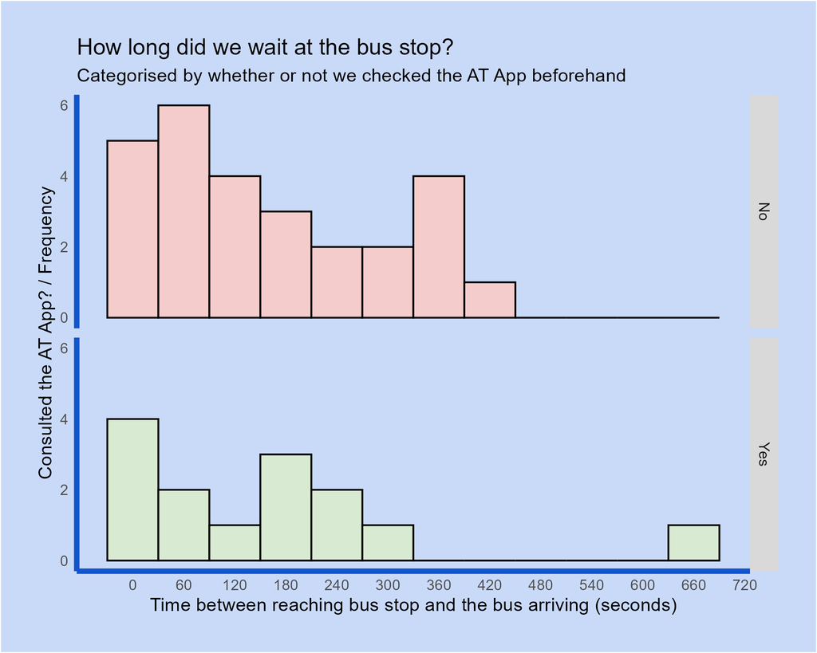

Histogram of wait times at the bus stop

## Average wait times

For my last plot, I split the two categorical variables into four - whether or not they’d checked the app and whether or not they had a deadline. The biggest group was No App, No Deadline.

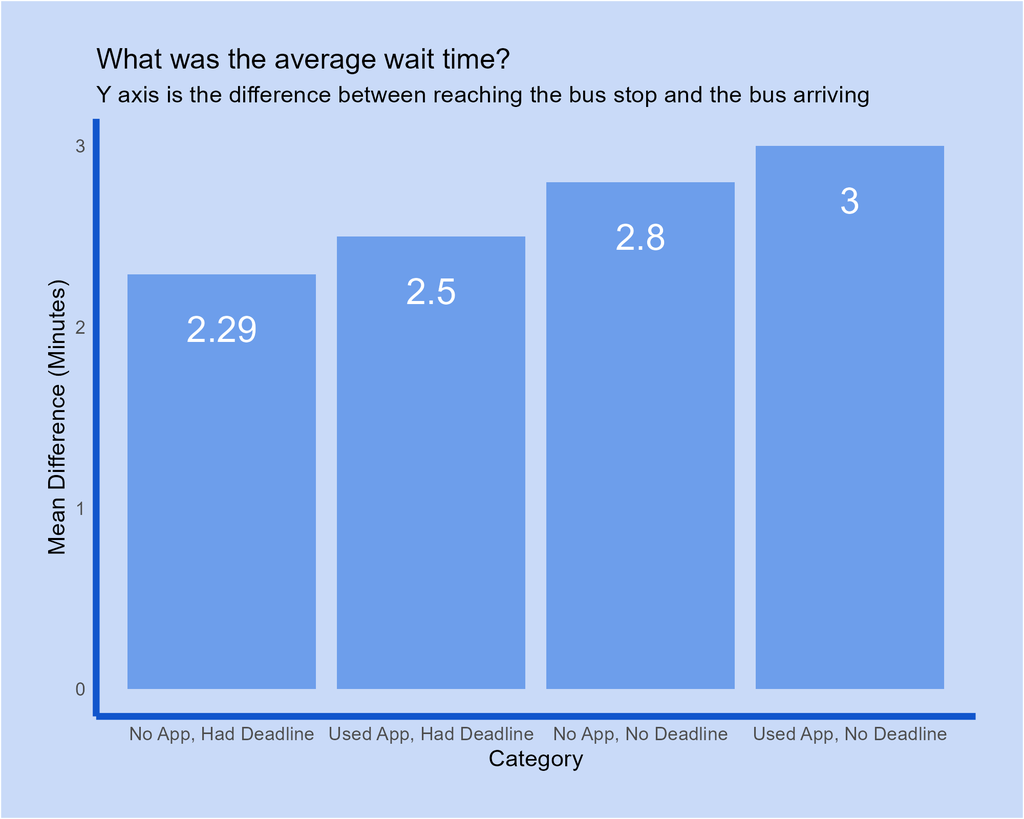

Bar chart showing average wait times per group

## Conclusion

From my (admittedly limited) data, it seems that there aren’t any significant correlations between wait times and the factors I measured (checking the app or not, having a deadline or not).

The main takeaway seems to be that no matter your situation, the buses will show up pretty promptly, which is great - that’s exactly how a public transport system should operate.